# PP2

## P P.2 Clasificación

Se comienza importando todas las liberías y funciones a utilizar. Esto asegura que el código tenga acceso a todas las herramientas pertinentes para el procesamiento de datos, creación de modelos y validación.

```python
import pandas as pd
import numpy as np
from sklearn.model_selection import train_test_split, cross_val_score
from sklearn.linear_model import LogisticRegression
from sklearn.discriminant_analysis import LinearDiscriminantAnalysis
from sklearn.tree import DecisionTreeClassifier, plot_tree
from sklearn.ensemble import BaggingClassifier, RandomForestClassifier, GradientBoostingClassifier
from sklearn.metrics import accuracy_score
from sklearn.preprocessing import LabelEncoder
from sklearn.multiclass import OneVsRestClassifier
import seaborn as sns
import matplotlib.pyplot as plt
```

**1.** Se cargan dos conjuntos de datos *train.csv* para entrenar el modelo y *test.csv* para probar el modelo después de entrenarlo. Se utiliza *data_tr.info()* para obtener un resumen de la estructura de los datos, como el tipo de datos y la cantidad de valores nulos. Así mismo, *data_tr.sample(10)* muestra 10 filas aleatorias del conjunto de datos para tener una idea general de su apariencia.

Se seleccionan solo las columnas numéricas tanto del conjunto de entrenamiento como el de prueba y se reemplazan los valores nulos por la media de cada columna numérica. Después de limpiar los valores nulos, los datos numéricos se vuelven a combinar con los datos no numéricos.

Se utiliza el *LabelEncoder* para convertir las variables categóricas en números, lo cual es necesario para que los modelos puedan procesarlas.

Se calcula la correlación entre las variables numéricas y se visualiza en un heatmap, lo que ayuda a identificar las relaciones entre las características del conjunto de datos.

Se separan las características (X) del objetivo (y), y luego se divide el conjunto de datos en entrenamiento y prueba con proporción 70/30.

```
<class 'pandas.core.frame.DataFrame'>
RangeIndex: 8693 entries, 0 to 8692
Data columns (total 14 columns):
 #   Column        Non-Null Count  Dtype
---  ------        --------------  -----
 0   PassengerId   8693 non-null   object
 1   HomePlanet    8492 non-null   object
 2   CryoSleep     8476 non-null   object
 3   Cabin         8494 non-null   object
 4   Destination   8511 non-null   object
 5   Age           8514 non-null   float64
 6   VIP           8490 non-null   object
 7   RoomService   8512 non-null   float64
 8   FoodCourt     8510 non-null   float64
 9   ShoppingMall  8485 non-null   float64
```

[output cut: 42 more lines]

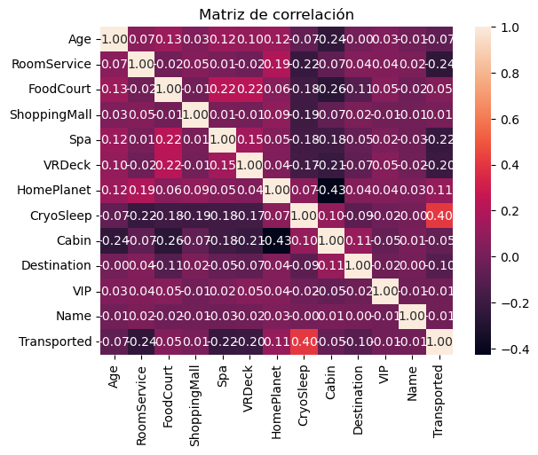

```python
data_tr=pd.read_csv('train.csv')
data_te=pd.read_csv('test.csv')

print(data_tr.info())
print(data_tr.sample(10))

data_tr_numerico = data_tr.select_dtypes(include=[np.number])
data_te_numerico = data_te.select_dtypes(include=[np.number])

data_tr_numerico.fillna(data_tr_numerico.mean(), inplace=True)
data_te_numerico.fillna(data_te_numerico.mean(), inplace=True)

data_tr_no_numerico = data_tr.select_dtypes(exclude=[np.number])
data_te_no_numerico = data_te.select_dtypes(exclude=[np.number])

data_tr=pd.concat([data_tr_numerico, data_tr_no_numerico], axis=1)
data_te=pd.concat([data_te_numerico, data_te_no_numerico], axis=1)

columnas_categoricas=data_tr.select_dtypes(include=[object]).columns
columnas_categoricas=columnas_categoricas[columnas_categoricas != 'PassengerId']

label_encoder=LabelEncoder()
for column in columnas_categoricas:
    data_tr[column]=label_encoder.fit_transform(data_tr[column].astype(str))

for column in columnas_categoricas:
    data_te[column]=data_te[column].apply(lambda x:label_encoder.transform([x])[0] if x in label_encoder.classes_ else -1)

data_tr=data_tr.drop('PassengerId', axis=1)
data_te_sin_id = data_te.drop('PassengerId', axis=1)

matriz_correlacion=data_tr.corr()
sns.heatmap(matriz_correlacion, annot=True, fmt='.2f')
plt.title('Matriz de correlación')
plt.show()

X = data_tr.drop('Transported', axis=1)
y = data_tr['Transported']

X_train, X_test, y_train, y_test = train_test_split(X, y, test_size=0.3, random_state=42)
```

La validación cruzada es una técnica para evaluar la generalización de un modelo. En lugar de usar solo un conjunto de entrenamiento y uno de prueba, se divide el conjunto de datos en varias particiones y el modelo se entrena y evalúa en cada una de ellas. Se realiza validación cruzada para asegurar que el modelo no esté sobreajustado a los datos de entrenamiento y tenga un buen rendimiento en datos no vistos.

```python
modelo_log= OneVsRestClassifier(LogisticRegression(max_iter=10000, solver='lbfgs'))
modelo_log.fit(X_train, y_train)
log_preds=modelo_log.predict(X_test)
log_accuracy=accuracy_score(y_test, log_preds)
print('Accuracy regresión logística:',log_accuracy)

log_vc=cross_val_score(modelo_log, X, y, cv=5)
print(f'Accuracy vc regresión logística: {log_vc.mean()}')
```

```
Accuracy regresión logística: 0.7710889570552147
Accuracy vc regresión logística: 0.7793639586260109
```

**3.** El Análisis Discriminante Lineal (LDA) es otro algoritmo de clasificación que se utiliza para encontrar una combinación lineal de características que mejor separen las clases en el conjunto de datos. LDA busca proyectar los datos en un espacio de menor dimensión de manera que las clases sean lo más separadas posible. LDA asume que las clases siguen una distribución normal, y busca maximizar la separación entre ellas. Al igual que en la regresión logística, aquí también se realiza validación cruzada para evaluar el desempeño del modelo de LDA.

```python
modelo_LDA=LinearDiscriminantAnalysis()
modelo_LDA.fit(X_train, y_train)
LDA_preds=modelo_LDA.predict(X_test)
LDA_accuracy=accuracy_score(y_test, LDA_preds)
print('Accuracy LDA:',LDA_accuracy)

LDA_vc=cross_val_score(modelo_LDA, X, y, cv=5)
print(f'Accuracy vc LDA: {LDA_vc.mean()}')
```

```
Accuracy LDA: 0.7496165644171779
Accuracy vc LDA: 0.7618782139385425
```

**4.** El árbol de decisión es un modelo fácil de interpretar y entender. Este construye un modelo a partir de una serie de decisiones binarias que llevan a la predicción de una clase. El modelo crea ramas de acuerdo con las características del conjunto de datos, dividiendo repetidamente el conjunto de datos en función de las características más relevantes hasta que se alcanza una decisión, llamada hoja. De nuevo, se aplica validación cruzada para verificar el rendimiento del árbol de decisión y asegurar que no esté sobreajustado.

```
Accuracy árbol de decisión: 0.7250766871165644
Accuracy vc árbol de decisión: 0.7202362242760844
```

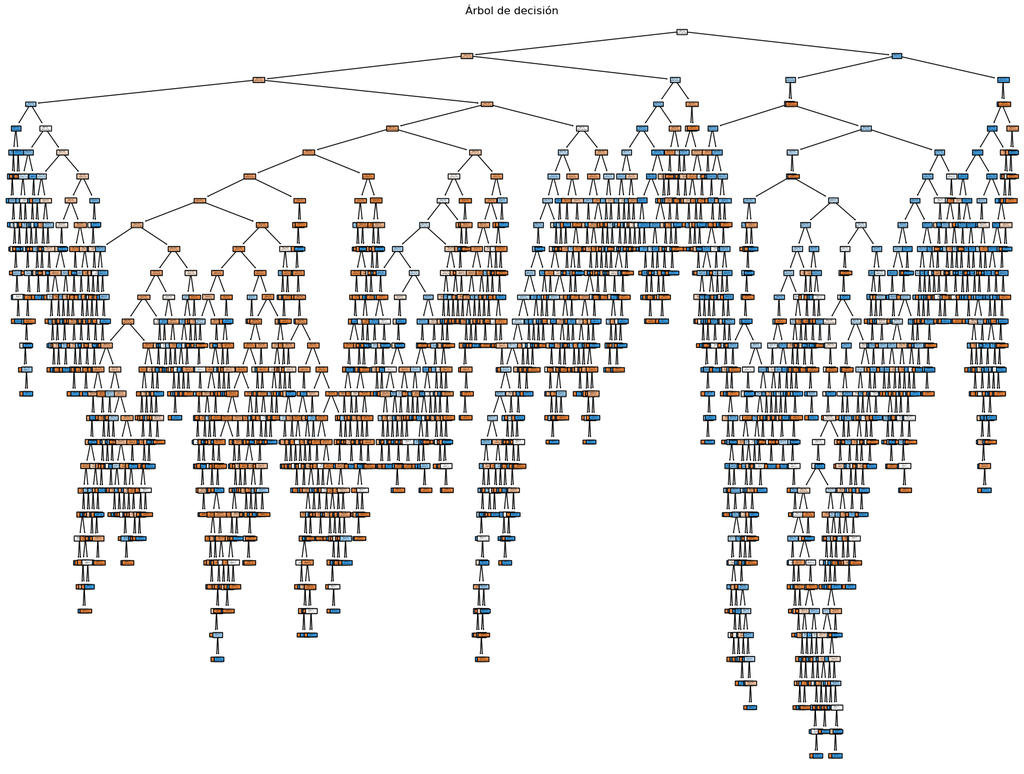

```python
modelo_arbol=DecisionTreeClassifier(random_state=42)
modelo_arbol.fit(X_train, y_train)
arbol_preds=modelo_arbol.predict(X_test)
arbol_accuracy=accuracy_score(y_test, arbol_preds)
print('Accuracy árbol de decisión:', arbol_accuracy)

arbol_vc=cross_val_score(modelo_arbol, X, y, cv=5)
print(f'Accuracy vc árbol de decisión: {arbol_vc.mean()}')

plt.figure(figsize=(20, 15))
plot_tree(modelo_arbol, feature_names=X.columns, class_names=['Not Transported', 'Transported'], filled=True)
plt.title('Árbol de decisión')
plt.show()
```

**5.** Bagging consiste en entrenar múltiples modelos en diferentes subconjuntos aleatorios de los datos (obtenidos por el muestreo con reemplazo) y luego promediar sus resultados. El propósito es reducir la varianza del modelo y mejorar la precisión, ya que la combinación de varios modelos tiende a ser más robusta. Se realiza validación cruzada sobre el modelo de bagging para asegurar que su rendimiento sea adecuado en datos no vistos.

```python
modelo_bagging=BaggingClassifier(random_state=42)
modelo_bagging.fit(X_train, y_train)
bagging_preds=modelo_bagging.predict(X_test)
bagging_accuracy=accuracy_score(y_test, bagging_preds)
print('Accuracy bagging:', bagging_accuracy)

bagging_vc= cross_val_score(modelo_bagging, X, y, cv=5)
print(f'Accuracy vc bagging: {bagging_vc.mean()}')
```

```
Accuracy bagging: 0.7749233128834356
Accuracy vc bagging: 0.7585450151569193
```

**6.** El Random forest es un algoritmo de ensemble que utiliza múltiples árboles de decisión entrenados con subconjuntos aleatorios de características y datos, ayudando a mejorar el rendimiento general. Se aplica validación cruzada al Random Forest para evaluar su capacidad de generalización.

```python
modelo_rf=RandomForestClassifier(random_state=42)
modelo_rf.fit(X_train, y_train)
rf_preds=modelo_rf.predict(X_test)
rf_accuracy=accuracy_score(y_test, rf_preds)
print('Accuracy random forest:', rf_accuracy)

rf_vc=cross_val_score(modelo_rf, X, y, cv=5)
print(f'Accuracy vc random forest: {rf_vc.mean()}')
```

```
Accuracy random forest: 0.7868098159509203
Accuracy vc random forest: 0.7804006244081655
```

**7.** El Boosting es una técnica de ensemble que combina múltiples modelos débiles (por lo general árboles de decisión) para formar un modelo fuerte. El modelo se entrena de manera secuencial, cada nuevo modelo corrige los errores de los modelos previos. *GradientBoostingClassifier* se utiliza para ajustar un conjunto de árboles de decisión de manera eficiente.

```python
modelo_boosting=GradientBoostingClassifier(random_state=42)
modelo_boosting.fit(X_train, y_train)
boosting_preds=modelo_boosting.predict(X_test)
boosting_accuracy=accuracy_score(y_test, boosting_preds)
print('Accuracy gradient boosting:', boosting_accuracy)

boosting_vc=cross_val_score(modelo_boosting, X, y, cv=5)
print(f'Accuracy vc gradient boosting: {boosting_vc.mean()}')
```

```
Accuracy gradient boosting: 0.7887269938650306
Accuracy vc gradient boosting: 0.7930546171860472
```

**8.** Comparar los modelos

Se crea una lista contiene los nombres de los modelos que se han entrenado en el proyecto, así como una que contiene las precisiones (accuracy) de cada uno de los modelos. Estas precisiones son los resultados obtenidos de las predicciones de cada modelo en los datos de prueba.

Se crea un gráfico de barras para mejor visualización de todas las accuracies obtenidas. Luego, se encuentra la mayor precisión entre los modelos y el índice de la mayor precisión en la lista accuracies. Esto indica en qué lugar de la lista *modelos* está el modelo con la mejor precisión. Usando el índice encontrado, se obtiene el nombre del modelo correspondiente en la lista *modelos*.

Posterior a esto se elige el modelo con el mejor accuracy, en este caso en específico boosting. Se utiliza el mejor modelo seleccionado para hacer predicciones sobre el conjunto de datos de prueba.

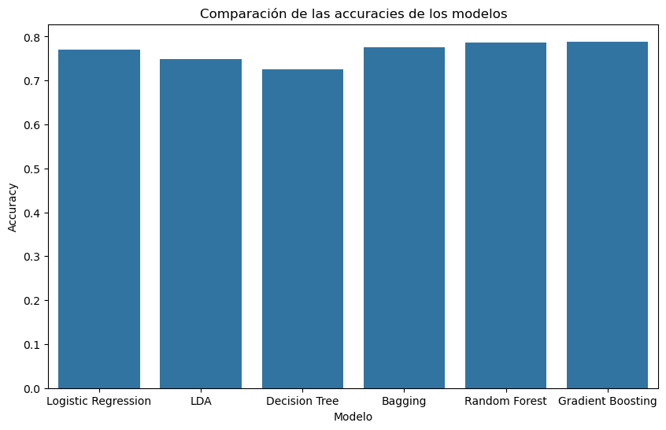

```
El mejor modelo es: Gradient Boosting con una accuracy de 0.7887269938650306
```

```python
modelos=['Logistic Regression', 'LDA', 'Decision Tree', 'Bagging', 'Random Forest', 'Gradient Boosting']
accuracies=[log_accuracy, LDA_accuracy, arbol_accuracy, bagging_accuracy, rf_accuracy, boosting_accuracy]

plt.figure(figsize=(10, 6))
sns.barplot(x=modelos, y=accuracies)
plt.title('Comparación de las accuracies de los modelos')
plt.xlabel('Modelo')
plt.ylabel('Accuracy')
plt.show()

mejor_accuracy=max(accuracies)
mejor_modelo_index=accuracies.index(mejor_accuracy)
mejor_modelo_nombre=modelos[mejor_modelo_index]

print('El mejor modelo es:', mejor_modelo_nombre,'con una accuracy de', mejor_accuracy)

mejor_modelo=modelo_boosting
preds_finales=mejor_modelo.predict(data_te_sin_id)
```

**9.** Guardar las predicciones en un archivo

Se crea un nuevo un DataFrame con dos columnas: *PassengerId*: siendo los ids de los pasajeros, y *Transported* la cual contiene las predicciones hechas por el modelo que están almacenadas en la variable preds_finales. Estas predicciones indican si cada pasajero fue transportado o no.

```python
entrega=pd.DataFrame({'PassengerId': data_te['PassengerId'], 'Transported':preds_finales})
entrega.to_csv('Archivo_final.csv', index=False)
```